### [Rajiv Jhangiani, Ph.D.](https://thatpsychprof.com/)

[Pedagogy](https://thatpsychprof.com/category/pedagogy/) [Students](https://thatpsychprof.com/category/students/)

# Why have students answer questions when they can write them?

[January 12, 2017January 12, 2017](https://thatpsychprof.com/why-have-students-answer-questions-when-they-can-write-them/) [Rajiv Jhangiani](https://thatpsychprof.com/author/rsjhangianigmail-com/) 15 Comments [assignments](https://thatpsychprof.com/tag/assignments/), [multiple-choice questions](https://thatpsychprof.com/tag/multiple-choice-questions/), [open pedagogy](https://thatpsychprof.com/tag/open-pedagogy/), [open textbooks](https://thatpsychprof.com/tag/open-textbooks/), [students](https://thatpsychprof.com/tag/students/)

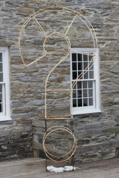

Questions by Alan Levine (CC-BY 2.0). Retrieved from https://flic.kr/p/mrQ1x1

I recently trialled a new assignment in my Social Psychology class: During each of the 10 weeks when there was no scheduled exam I asked my students to write multiple-choice questions. That’s right, they *wrote* questions instead of merely answering them.

From a pedagogical perspective, I really wanted my students to achieve a deeper level of understanding (e.g., the level it takes in order to craft three plausible distractors). However, this assignment also served a pragmatic purpose in that [the open textbook that I use for this course](http://opentextbc.ca/socialpsychology) (and that I helped revise) does not yet have a readymade question bank. By asking my students to craft and peer-review multiple-choice questions based on the concepts covered that week (and scaffolding this process over the semester), I considered I had a budding [open pedagogy](https://opencontent.org/blog/archives/2975) project on my hands.

Here’s how it went:

1. The students were asked to write 4 questions each week, 2 factual (e.g., a definition or evidence-based prediction) and 2 applied (e.g., scenario-type).
2. For the first two weeks they wrote just one plausible distractor (I provided the question stem, the correct answer, and 2 plausible distractors). They also peer reviewed questions written by 3 of their (randomly assigned) peers. This entire procedure was double blind and performed using Google forms for the submission and Google sheets for the peer review.
3. For the next two weeks they wrote two plausible distractors (the rest of the procedure was the same).
4. For the next two weeks they wrote all 3 plausible distractors (the rest of the procedure was the same).
5. For the remainder of the semester they wrote the stem, the correct answer, and all the distractors.

I adapted existing guidelines about how to write effective multiple-choice distractors and how to provide constructive peer feedback and produced these two brief guides:

[Guidelines for writing effective distractors for multiple-choice questions](http://thatpsychprof.com/wp-content/uploads/2016/12/Guidelines-for-writing-effective-distractors-for-multiple-choice-questions.pdf)

[Guidelines for providing constructive peer feedback](http://thatpsychprof.com/wp-content/uploads/2016/12/Guidelines-for-providing-constructive-peer-feedback.pdf)

The result? My small class of 35 students wrote 1400 questions in the span of 10 weeks! And although I wouldn’t consider this a polished question bank ready for use by other instructors, I still consider this assignment to have been a success because the questions steadily improved over the semester (the experience of serving as peer reviewers was especially useful to the students when constructing their own questions). The students were also buoyed and motivated by my practice of including a few of their best questions on each of the three course exams. Looking forward, I plan to have my next cohort of Social Psychology students revise and add to this bank. I figure that it will take only a couple of semesters for us to provide the commons with a high-quality question bank, something that will enable even more instructors to adopt this open textbook.

If you have attempted something similar or would even like to collaborate with me on this assignment, please write a comment below or otherwise get in touch. Your feedback is very welcome.

### 15 thoughts on “Why have students answer questions when they can write them?”

- [Caitlin Faas](http://www.drcaitlinfaas.com/)

  January 13, 2017 at 5:30 am

  Permalink

  I love this idea, Rajiv! I’d like to use it this semester with my Research Preparation class (both methods and statistics in the course). Let’s talk!

  [Reply](https://thatpsychprof.com/why-have-students-answer-questions-when-they-can-write-them/?replytocom=5488#respond)
  - Rajiv JhangianiPost author

    January 14, 2017 at 8:54 am

    Permalink

    Wonderful! In case it works for the assignment, this open textbook for Research Methods needs a question bank: http://opentextbc.ca/researchmethods/  
    Please let me know how I can support you. Happy to set up a virtual chat.

    [Reply](https://thatpsychprof.com/why-have-students-answer-questions-when-they-can-write-them/?replytocom=5495#respond)
    - Rendani

      February 17, 2017 at 2:58 am

      Permalink

      Hi Rajiv, I am touched by your teaching method. I assure you that those students who took part in that process are now confident and encouraged to do more. I strongly believe that learning by doing is the best method ever. It is something that I will consider doing with my students. I think it is an excellent way of creating knowledge.

      Good going..

      [Reply](https://thatpsychprof.com/why-have-students-answer-questions-when-they-can-write-them/?replytocom=5541#respond)
- Paul

  January 13, 2017 at 7:49 am

  Permalink

  I love this idea! Not only do the students learn more deeply, they also learn ways to take charge of their learning. We did something simliar, although much more rudimentary, in our Internet Course (http://theinternetcourse.net/?s=midterm) which I think worked out well, for what it was. I have been wondering about how the ds106 assignment bank (http://assignments.ds106.us/) could be adapted for this type of purpose, so that creating questions could become an ongoing component of almost any course.

  [Reply](https://thatpsychprof.com/why-have-students-answer-questions-when-they-can-write-them/?replytocom=5490#respond)
  - Rajiv JhangianiPost author

    January 14, 2017 at 9:04 am

    Permalink

    Thank you Paul. I love what you did in your course, especially that the midterm was open web. I am now developing a version of this assignment for the OERu’s forthcoming Introduction to Psychology course (see http://course.oeru.org/ipsy101/ for the first of three micro-courses currently under construction). An additional challenge here is that these micro-courses will be asynchronous.

    [Reply](https://thatpsychprof.com/why-have-students-answer-questions-when-they-can-write-them/?replytocom=5497#respond)
  - Rendani

    February 17, 2017 at 3:03 am

    Permalink

    Hi Paul,  
    This is exciting and I hope more students could get involved and ownership of learning. I am more encouraged to find ways of incorporating this so that students can take charge of learning.

    Thanks for sharing.

    [Reply](https://thatpsychprof.com/why-have-students-answer-questions-when-they-can-write-them/?replytocom=5542#respond)
- [Maha Bali](http://blog.mahabali.me/)

  January 14, 2017 at 7:56 am

  Permalink

  Love this. A prof here experimented w student-generated exams in engineering – they created exams and scoring criteria and took each other’s exams.

  I am not a fan of MCQS but thinking of how doing this exercise can really enhance students’ metacognition and exam technique in other courses. I say this because after learning about MCQ design i was able to pass medical tests and driving tests (w/o much background knowledge). Still MCQ for formative assessment can be really helpful, so not at all discounting the value of what u have done and how innovative it is

  [Reply](https://thatpsychprof.com/why-have-students-answer-questions-when-they-can-write-them/?replytocom=5494#respond)
  - Rajiv JhangianiPost author

    January 14, 2017 at 8:57 am

    Permalink

    Thank you Maha. Love the idea of student-created exams. In this assignment only the best questions made it into the exams but the students also had access to all of the written questions to help them review. I am afraid MCQ testing is ubiquitous in my discipline, which is why the absence of a question bank can deter some potential open textbook adopters.

    [Reply](https://thatpsychprof.com/why-have-students-answer-questions-when-they-can-write-them/?replytocom=5496#respond)
- Pingback: [Pragmatism vs. Idealism and the Identity Crisis of OER Advocacy – Rajiv Jhangiani, Ph.D.](http://thatpsychprof.com/pragmatism-vs-idealism-and-the-identity-crisis-of-oer-advocacy/)
- [Bob Bodily](https://bobbodily.com/)

  August 3, 2017 at 9:50 pm

  Permalink

  Rajiv,  
  I love this post. Good work! It’s kind of humorous that I emailed you about students writing questions before I read your blog post on the topic. When you teach another course we will have to connect again about the platform I have been developing to support this type of teaching method.

  [Reply](https://thatpsychprof.com/why-have-students-answer-questions-when-they-can-write-them/?replytocom=5811#respond)
- Pingback: [Day Three: Open Assessment – ANU Online Coffee Courses](https://anuonline.weblogs.anu.edu.au/2017/10/25/day-three-open-assessment/)
- Pingback: [Compile a question bank, February 2018 Sustainable Assignment | Teaching & Learning Excellence Division Updates](http://sites.austincc.edu/tledupdates/compile-a-question-bank-february-2018-sustainable-assignment/)
- Pingback: [Helen Taylor Lane](https://helentlane.wordpress.com/2019/03/21/137/)
- Pingback: [Why have students answer questions when they can write them? – Teaching & Learning Commons](http://wordpress.kpu.ca/tlcommons/why-have-students-answer-questions-when-they-can-write-them/)
- Cristine Gusmão

  March 4, 2021 at 3:48 pm

  Permalink

  Hi Rajiv, it’s nice to meet you here and learn about your approach in the classroom.

  I don’t work with questions, but I encourage my students to develop drafts even small papers. Last year I coordinated the + Saberes Project. An extension action that promoted a set of challenges in the area of Biomedical Engineering. All students had to develop a short article related to a specific area of health, technology or education. The article was related to a recorded presentation with a specialist in the chosen field. All materials are open and licensed under a Creative Commons license. In this version the materials are still in Portuguese – https://www.openeducationweek.org/resources/saberes-project

  [Reply](https://thatpsychprof.com/why-have-students-answer-questions-when-they-can-write-them/?replytocom=16212#respond)